# Master RMD

2023-03-06

# Load Libraries

```r
library(dplyr)
library(ggplot2)
library(descr)
library(tidyverse)
library(labelled)
library(janitor)
library(pastecs)
library(haven)
library(readstata13)
library(sna)
library(GGally)
library(reshape2)
library(viridis)
library(lme4)
```

# Import Data

```r
w1_ym <- read.dta13("Data-Stata/our_data/w1_ym.dta", convert.factors = F)
w1_yc <- haven::read_dta("Data-Stata/our_data/w1_yc.dta")
w123_tracking <- read.dta13("Data-Stata/w123_tracking.dta")
```

## Tracking data Wave 1

```r
freq(w123_tracking$ps_w1_yc, plot = FALSE)
```

```
## w123_tracking$ps_w1_yc
##                    Frequency  Percent
## question not asked         0   0.0000
## not participated           9   0.3603
## participated            2489  99.6397
## Total                   2498 100.0000
```

## Tracking data - Wave 2

```r
freq(w123_tracking$ps_w2_yRV, plot = FALSE)
```

```
## w123_tracking$ps_w2_yRV
##                                         Frequency  Percent
## question not asked                              0   0.0000
## participated: self-completion at school      1760  70.4564
## participated: telephone                       686  27.4620
## participated: self-completion at home          38   1.5212
## participated: online                           14   0.5604
## not participated: reason unknown                0   0.0000
## Total                                        2498 100.0000
```

```r
freq(w123_tracking$ps_w2_ym, plot = FALSE)
```

```
## w123_tracking$ps_w2_ym
##                    Frequency Percent
## question not asked         0       0
## not participated           0       0
## participated            2498     100
## Total                   2498     100
```

*Wave 2 DOES NOT have friends questionnaire!

738 students DID NOT respond to Wave 2 classmates questionnaire.

```r
freq(w123_tracking$ps_w2_yc, plot = FALSE)
```

```
## w123_tracking$ps_w2_yc
##                    Frequency Percent
## question not asked         0    0.00
## not participated         738   29.54
## participated            1760   70.46
## Total                   2498  100.00
```

## Tracking data - Wave 3

```r
freq(w123_tracking$ps_w3_yRV, plot = FALSE)
```

```
## w123_tracking$ps_w3_yRV
##                                         Frequency Percent
## question not asked                              0   0.000
## participated: self-completion at school         0   0.000
## participated: telephone                      2013  80.584
## participated: self-completion at home         369  14.772
## participated: online                          116   4.644
## not participated: reason unknown                0   0.000
## Total                                        2498 100.000
```

All 2498 participants responded to Wave 3 Youth Main questionnaire.

```r
freq(w123_tracking$ps_w3_ym, plot = FALSE)
```

```
## w123_tracking$ps_w3_ym
##                    Frequency Percent
## question not asked         0       0
## not participated           0       0
## participated            2498     100
## Total                   2498     100
```

17 participants DID NOT respond to Wave 3 Youth Friends (5 best friends) questionnaire.

```r
freq(w123_tracking$ps_w3_yf, plot = FALSE)
```

```
## w123_tracking$ps_w3_yf
##                    Frequency  Percent
## question not asked         0   0.0000
## not participated          17   0.6805
## participated            2481  99.3195
## Total                   2498 100.0000
```

Wave 3 DOES NOT have classmates questionnaire!

Note: We decided to work with the wave 1 as 738 students DID NOT respond to Wave 2 classmates questionnaire, and wave 3 does not contain classmates component.

# Exploring Data we Use for Network Measures

#### Count number of classes by school:

```r
# total number of school -- 80
w1_yc <- haven::read_dta("Data-Stata/our_data/w1_yc.dta")
w1_yc %>%
  group_by(schoolidCUF) %>%
  summarise(n_class = length(unique(classidCUF))) %>%
  group_by(n_class) %>%
  summarise(count_by_num_class=n(),
            percent = count_by_num_class/80)
```

```
## # A tibble: 2 × 3
##   n_class count_by_num_class percent
##     <int>              <int>   <dbl>
## 1       1                 28    0.35
## 2       2                 52    0.65
```

65% of all 80 schools in our subsample examined 2 classes

#### Count Students by School:

```r
w1_yc %>%
  group_by(schoolidCUF) %>%
  summarise(total_obs = n()) %>% # NUM of participants from each school
  arrange(desc(total_obs)) |>
  ungroup()
```

```
## # A tibble: 80 × 2
##    schoolidCUF total_obs
##          <dbl>     <int>
##  1        3928        43
##  2        1662        42
##  3        2280        40
##  4        1513        39
##  5        2327        39
##  6        1730        37
##  7        5044        37
##  8        2487        36
##  9        4546        36
## 10        1479        33
## # … with 70 more rows
```

#### Example Network from School 3928:

```r
school3928 <- w1_yc %>%
  filter(schoolidCUF == 3928)

# exclude useless variables
school3928 <- school3928 %>%
  select(-schtype_geRV, -y1_intdat_ycRV, -y1_vers_yc)
#colnames(school3928)
```

[Tutorial on labelled/unlabelled object in R](https://cran.r-project.org/web/packages/labelled/vignettes/intro_labelled.html)

```r
# data only includes friendship measures
network3928 <- school3928 %>%
  select(youthidCUF, 4:210)

# code out missing values
network3928_clean <- network3928 %>%
  labelled::to_factor() %>%  # changed labelled/haven_labelled object to factor
  lapply(function(x) as.numeric(as.character(x))) %>% # coerce all vars to be numeric
  data.frame()
```

Relevant tutorial on networks in R [HERE](https://rstudio-pubs-static.s3.amazonaws.com/470420_91f1d47c90c54b879aa08ce93fa66730.html)

Storing a network using an adjacency matrix also helps storing network attributes (by using the rownames of the adjacency matrix and assigning those rownames the corresponding attributes).

Following the workflow described above, we are going to create an empty matrix with the unique student IDs as the row and column names so that we can later populate them with the information from the edgelist.

```r
students <- unique(network3928_clean$youthidCUF)
mat <- matrix(0, nrow=length(students), ncol = length(students))
colnames(mat) <- as.character(students)
rownames(mat) <- as.character(students)
# A glimpse of what this look lik
mat[1:4,1:4]
```

```
##          39280101 39280102 39280103 39280104
## 39280101        0        0        0        0
## 39280102        0        0        0        0
## 39280103        0        0        0        0
## 39280104        0        0        0        0
```

We are now going to use a loop to fill the matrix: 1 whenever there is a friendship tie in students, 0 otherwise.

```r
i <- 1
for (i in 1:nrow(network3928_clean)) {
  row.index <- which(students == network3928_clean[i,1])
  col.index <- which(students == network3928_clean[i,3]) # col 3 is best friends 1
  mat[row.index, col.index] <- 1
}
mat[1:4,]
```

```
##          39280101 39280102 39280103 39280104 39280105 39280106 39280107
## 39280101        0        0        0        0        0        0        0
## 39280102        0        0        0        1        0        0        0
## 39280103        0        0        0        0        0        0        0
## 39280104        0        1        0        0        0        0        0
##          39280108 39280109 39280110 39280112 39280113 39280114 39280115
## 39280101        0        0        0        0        0        0        0
## 39280102        0        0        0        0        0        0        0
## 39280103        0        0        0        0        0        0        0
## 39280104        0        0        0        0        0        0        0
##          39280117 39280118 39280119 39280120 39280121 39280122 39280123
## 39280101        0        0        1        0        0        0        0
## 39280102        0        0        0        0        0        0        0
## 39280103        1        0        0        0        0        0        0
## 39280104        0        0        0        0        0        0        0
```

[output cut: 20 more lines]

##### Friendship Network at School 3928 –> All 5 best friends

Using `pivot_longer()` functions in `tidyverse` to reshape our data from wide to long

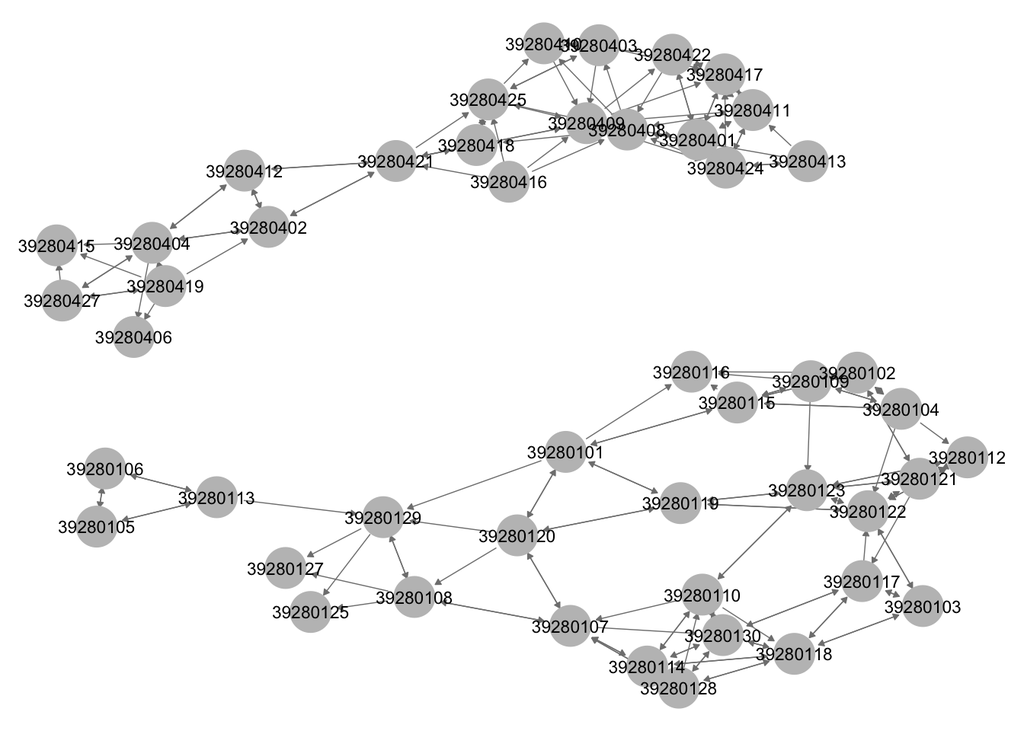

```r
bfs3928 <- network3928_clean %>%
  select(youthidCUF, y1_bfs_1:y1_bfs_5) %>%
  pivot_longer(cols = y1_bfs_1:y1_bfs_5,
               names_to = "best_friends",
               values_to = "friendid")

bfs3928 <- bfs3928 %>%
  select(youthidCUF, friendid) %>%
  filter(!is.na(friendid)) %>%
  mutate(youthidCUF = as.character(youthidCUF),
         friendid = as.character(friendid))

bfs_nw <- network(bfs3928, matrix.type = "edgelist")
#Or we can do it by using the adjacency matrix:
#nw2 <- network(mat, directed = TRUE)
ggnet2(bfs_nw,
       label = TRUE,
       label.size = 3,
       arrow.size = 3,
       arrow.gap = .03)
```

# Create Network Measures for all data in Wave I

### Count Reciprocity (n mutual friends, non-reciprocal)

```r
# data only includes friendship measures
w1_reciprocal <- w1_yc %>%
  select(youthidCUF, 7:210) %>%
  mutate(y1_bfs_0 = as.numeric(as.character(y1_bfs_0)))

# code out missing values
w1_reciprocal <- w1_reciprocal %>%
  #labelled::to_factor() %>%  # changed labelled/haven_labelled object to factor
  lapply(function(x) as.numeric(as.character(x))) %>% # coerce all vars to be numeric
  data.frame()

w1_reciprocal[w1_reciprocal < 0] <- NA

# exclude the 4 students did not respond to best friends questions at all
descr::freq(w1_yc$y1_bfs_0, plot=FALSE)
```

```
## c1: who are your best friends in class (nobody)
##       Frequency  Percent
## -88           4   0.2282
## 0          1721  98.1746
## 1            28   1.5973
## Total      1753 100.0000
```

```r
descr::freq(w1_reciprocal$y1_bfs_0, plot=FALSE)
```

```
## w1_reciprocal$y1_bfs_0
##       Frequency  Percent Valid Percent
## 0          1721  98.1746        98.399
## 1            28   1.5973         1.601
## NA's          4   0.2282
## Total      1753 100.0000       100.000
```

```r
#na_students <- c(52280219,42110503,31080205,29840209)
#w1_pos <- w1_pos %>%
#  filter(!youthidCUF %in% na_students)
```

```r
w1_reciprocal_long <- w1_reciprocal %>%
  filter(!is.na(y1_bfs_0)) %>%
  select(youthidCUF, y1_bfs_1:y1_bfs_5) %>%
  pivot_longer(cols = y1_bfs_1:y1_bfs_5,
               names_to = "best_friends",
               values_to = "friendid") %>%
  select(youthidCUF, friendid)

length(unique(w1_reciprocal_long$youthidCUF))
```

```
## [1] 1749
```

```r
#no_friends <- w1_pos$youthidCUF[w1_pos$y1_bfs_0 == 1]
#no_friends_id
```

```r
w1_bfs <- w1_reciprocal_long %>%
  mutate(hasfriend = ifelse(is.na(friendid),0,1)) %>%
  group_by(youthidCUF) %>%
  summarise(num_bfs = sum(hasfriend))

descr::freq(w1_bfs$num_bfs, plot = FALSE)
```

```
## w1_bfs$num_bfs
##       Frequency Percent
## 0            30   1.715
## 1            64   3.659
## 2           190  10.863
## 3           297  16.981
## 4           343  19.611
## 5           825  47.170
## Total      1749 100.000
```

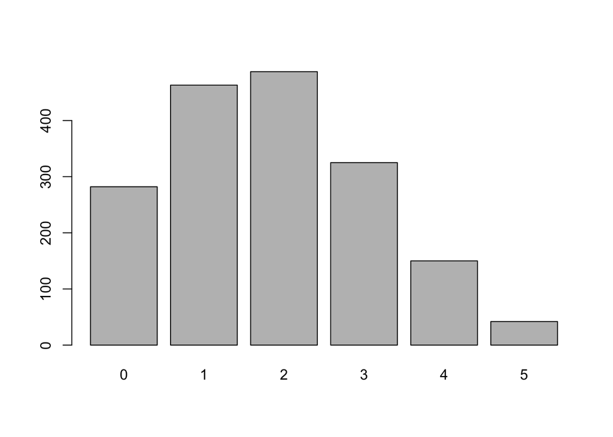

```
## fred_mat$n_mutual_bfs
##       Frequency Percent
## 0           282  16.123
## 1           463  26.472
## 2           487  27.844
## 3           325  18.582
## 4           150   8.576
## 5            42   2.401
## Total      1749 100.000
```

```r
students <- unique(w1_bfs$youthidCUF)
fred_mat <- as.data.frame(students) %>%
  mutate(n_mutual_bfs = 0) |>
  mutate(non_reciprocal = 0)
colnames(fred_mat)[1] <- "youthidCUF"

for (i in 1 : nrow(fred_mat)) {
  id = fred_mat[i,1]
  dt = w1_reciprocal_long %>% filter(youthidCUF == id)
  bfs = unique(dt$friendid)
  for (bf in bfs) {
    bf_data = w1_reciprocal_long %>% filter(youthidCUF == bf)
    if (id %in% unique(bf_data$friendid)){
      fred_mat[i,2] = fred_mat[i,2] + 1
      }
    else if (! id %in% unique(bf_data$friendid)){
      fred_mat[i,3] = fred_mat[i,3] + 1
    }
    else {next}
  }
}

descr::freq(fred_mat$n_mutual_bfs)
```

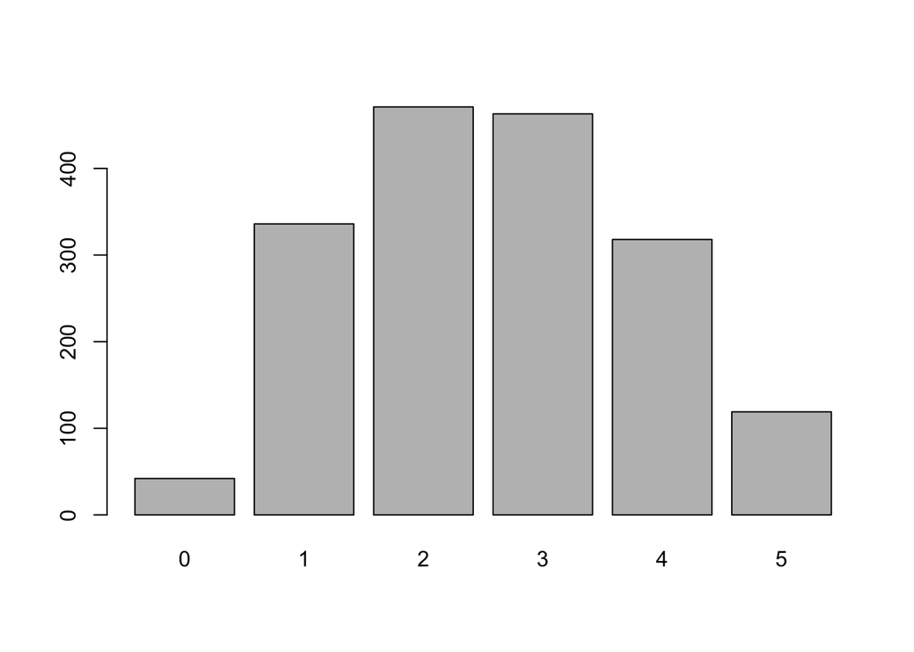

```
## fred_mat$non_reciprocal
##       Frequency Percent
## 0            42   2.401
## 1           336  19.211
## 2           471  26.930
## 3           463  26.472
## 4           318  18.182
## 5           119   6.804
## Total      1749 100.000
```

```r
descr::freq(fred_mat$non_reciprocal)
```

```r
w1_reciprocal_yc <- merge(fred_mat,w1_bfs,by="youthidCUF")
#write_dta(w1_pos_yc, "Data-Stata/our_data/w1_pos_yc.dta")
```

Calculate other measures of reciprocity (Followers?)

### Positive Friendship Network

```r
w1_yc <- read.dta13("Data-Stata/our_data/w1_yc.dta",convert.factors =F)
class1 <- w1_yc %>%
  select(-y1_intdat_ycRV, -y1_vers_yc)
# look at the structur of data
#str(w1_class)
```

In Sanne’s code: “# add health students mention on average 6 or 7 friends. # but these are american students who have lower thresholds of friendship nominations # drop cases according to Kruse & Jacobs Q: do we also want to drop these cases?

```r
# add health students mention on average 6 or 7 friends.
# but these are american students who have lower thresholds for friendship nominations
# drop cases according to Kruse & Jacobs
class1$n <- 1
myvars <- c("n", "y1_nnomineeG")
npupils <- aggregate(class1[myvars], sum, by = list(class1$classidCUF))
keep <- npupils[npupils$n > 10 & npupils$y1_nnomineeG <=4, 1]

class1 <- class1[class1$classid %in% keep, ]
class1 <- class1[class1$y1_classid_matchG == 1, ]
class1 <- class1[class1$y1_p_participantsG >= .75, ]
class1 <- class1[class1$y1_p_invalidnomsG <= .1, ]
```

### Data Preprocessing for Building Positive Friendship Network

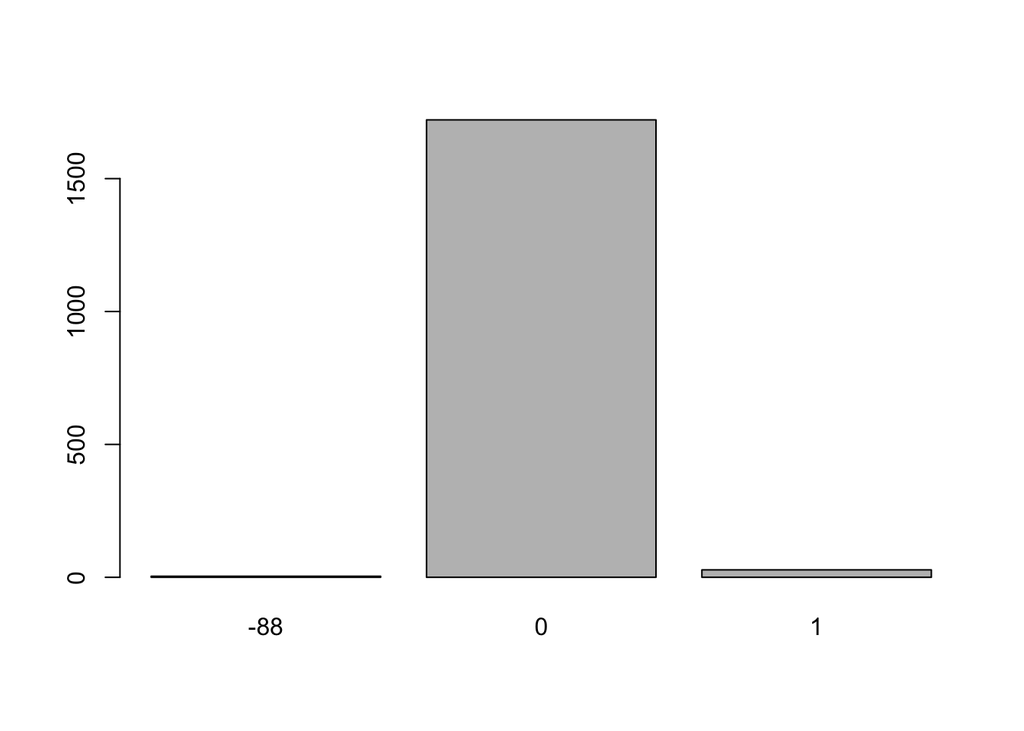

```
## class1$y1_bfs_0
##       Frequency  Percent
## -88           4   0.2282
## 0          1721  98.1746
## 1            28   1.5973
## Total      1753 100.0000
```

```r
# code out missing values
# select friendship measures and set missing values to NA
pos_vars <- c("y1_bfs_1", "y1_bfs_2", "y1_bfs_3", "y1_bfs_4", "y1_bfs_5")
class1[pos_vars][class1[pos_vars] < 0] <- NA
descr::freq(class1$y1_bfs_0)
```

Q: For those who did not report having best friend in class, do we remove them or include them and make their # class best friends = 0?

```r
# reshape to long
class1.l <- class1 %>%
  select(youthidCUF, y1_bfs_1:y1_bfs_5) %>%
  pivot_longer(cols = y1_bfs_1:y1_bfs_5,
               names_to = "best_friends",
               values_to = "alteridCUF") %>%
  select(youthidCUF, alteridCUF) %>%
  na.omit() # remove NAs for building network
print("Number of Unique Students in subsample")
```

```
## [1] "Number of Unique Students in subsample"
```

```r
length(unique(class1.l$youthidCUF))
```

```
## [1] 1719
```

```r
### Sanne's code
#myvars <- c("youthidCUF", "y1_bfs_1", "y1_bfs_2", "y1_bfs_3", "y1_bfs_4", "y1_bfs_5")
#class1.l <- reshape(class1[myvars], varying = myvars[-1], v.names = "alterid", timevar = "friend", idvar = "youthidCUF", times =myvars[-1], direction = "long")
```

```r
myids <- as.data.frame(unique(class1[c("youthidCUF","classidCUF")]))
classids <- unique(class1$classidCUF)
class1.l <- merge(class1.l, myids, by = "youthidCUF", all.x = TRUE)
classids <- unique(class1.l$classid)

nclass <- length(unique(class1.l$classid))
print("Number of classes in subsample")
```

```
## [1] "Number of classes in subsample"
```

```r
nclass
```

```
## [1] 132
```

```r
# make sure you take only the last two digits of youthid otherwise sna
# thinks that there are a thousand actors
class1.l <- class1.l %>%
  mutate(youthid = youthidCUF %% 100,
         alterid = alteridCUF %% 100) %>%
  select(youthid, alterid, classidCUF)
```

### Make Positive Friendship Network for each class

```r
el.list <- list()
class.list <- list()

for (i in 1:nclass){
  el.list[[i]] <- class1.l[class1.l$classidCUF == classids[i],]
  class.list[[i]] <- classids[i]
}

net.list <- lapply(el.list, as.network.matrix, matrix.type = "edgelist",
 ignore.eval = FALSE, names.eval = "classidCUF")
```

### Visualization of Positive Network 1 – classidCUF 102001

Q:

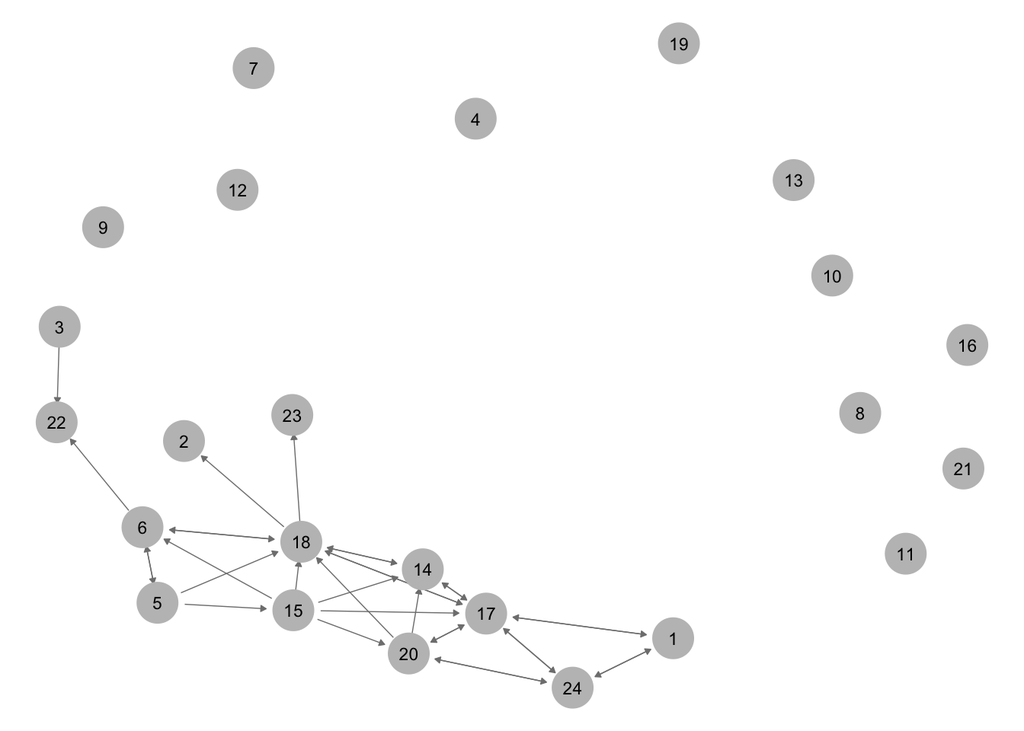

```r
ggnet2(net.list[[1]],
       label = TRUE,
       label.size = 3,
       arrow.size = 3,
       arrow.gap = .03)
```

### Calculate Positive Friendship Network measures

```r
mat.list <- lapply(net.list, as.matrix)
indegree.list <- lapply(mat.list, degree, cmode = "indegree", gmode = "digraph", diag = FALSE)
outdegree.list <- lapply(mat.list, degree, cmode = "outdegree", gmode = "digraph", diag = FALSE)
#bonpow.list <- lapply(mat.list, bonpow, diag = FALSE)
  # error? singular?
```

```r
a.list <- lapply(net.list, get.vertex.attribute, "vertex.names")
netm <- mapply(cbind, a.list, class.list, indegree.list, outdegree.list)
netm <- lapply(netm, as.data.frame)
netm <- as.data.frame(do.call(rbind, netm))
names(netm) <- c("youthid", "classid", "pos_indegree", "pos_outdegree")

# computate isolate measure
pos_netm <- netm %>%
  mutate(pos_isolate = ifelse(pos_indegree == 0 & pos_outdegree == 0, 1, 0),
         youthid_chr = as.character(youthid),
         classid_chr = as.character(classid),
         youthid_nchr = nchar(youthid_chr) # count the number of characters
         )

# add 0 to single digit youthid
pos_netm$youthid_chr[netm$youthid_nchr == 1] <- paste0("0", netm$youthid_chr[netm$youthid_nchr == 1])

# change to numeric youthid
pos_netm$youthid <- as.numeric(paste0(pos_netm$classid_chr, pos_netm$youthid_chr))
pos_netm <- pos_netm |>
  select(youthid, classid, pos_indegree, pos_outdegree, pos_isolate)
```

```r
#haven::write_dta(pos_netm, "Data-Stata/our_data/w1_pos_netm.dta")
```

## Negative Friendship Network

### Data Preprocessing for Building Negative Friendship Network

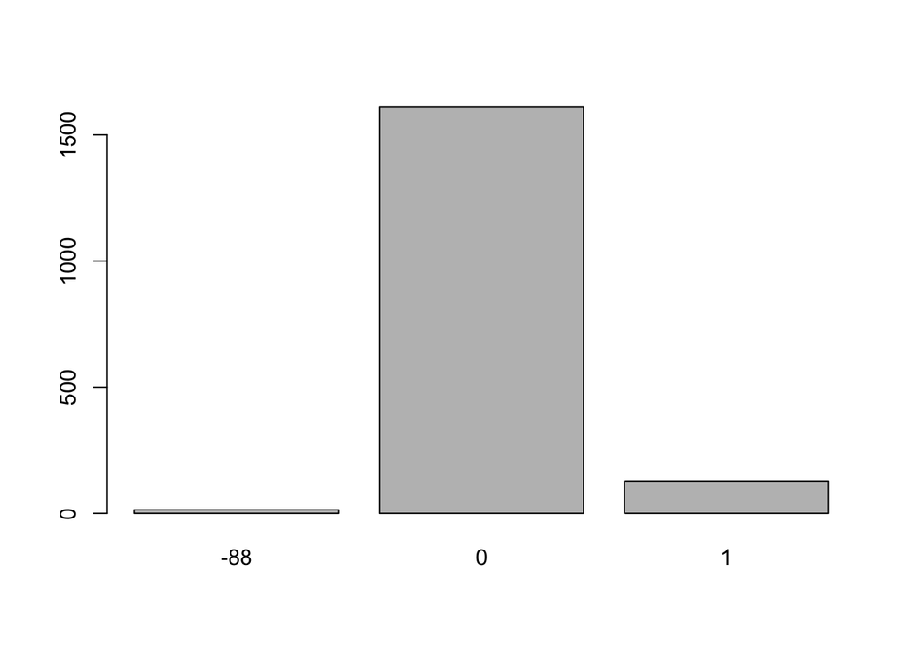

```
## class1$y1_sit_0
##       Frequency  Percent
## -88          14   0.7986
## 0          1612  91.9566
## 1           127   7.2447
## Total      1753 100.0000
```

```r
# code out missing values
# select friendship measures and set missing values to NA
neg_vars <- c("y1_sit_1", "y1_sit_2", "y1_sit_3", "y1_sit_4", "y1_sit_5")
class1[neg_vars][class1[neg_vars] < 0] <- NA
descr::freq(class1$y1_sit_0)
```

Q: For those who did not report having someone they don’t wanna sit with in class, do we remove them or include them and make their # class best friends = 0?

```r
# reshape to long
neg_class1.l <- class1 %>%
  select(youthidCUF, y1_sit_1:y1_sit_5) %>%
  pivot_longer(cols = y1_sit_1:y1_sit_5,
               names_to = "bad_friends",
               values_to = "alteridCUF") %>%
  select(youthidCUF, alteridCUF) %>%
  na.omit() # remove NAs for building network
print("Number of students in negative subsample")
```

```
## [1] "Number of students in negative subsample"
```

```r
length(unique(neg_class1.l$youthidCUF))
```

```
## [1] 1610
```

```r
### Sanne's code
#myvars <- c("youthidCUF", "y1_bfs_1", "y1_bfs_2", "y1_bfs_3", "y1_bfs_4", "y1_bfs_5")
#class1.l <- reshape(class1[myvars], varying = myvars[-1], v.names = "alterid", timevar = "friend", idvar = "youthidCUF", times =myvars[-1], direction = "long")
```

```r
myids <- as.data.frame(unique(class1[c("youthidCUF","classidCUF")]))
classids <- unique(class1$classidCUF)
neg_class1.l <- merge(neg_class1.l, myids, by = "youthidCUF", all.x = TRUE)
classids <- unique(neg_class1.l$classid)

nclass <- length(unique(neg_class1.l$classid))
print("Number of Classes in Negative network")
```

```
## [1] "Number of Classes in Negative network"
```

```r
nclass
```

```
## [1] 132
```

```r
# make sure you take only the last two digits of youthid otherwise sna
# thinks that there are a thousand actors
neg_class1.l <- neg_class1.l %>%
  mutate(youthid = youthidCUF %% 100,
         alterid = alteridCUF %% 100) %>%
  select(youthid, alterid, classidCUF)
```

### Make Negative Friendship Network for each class

```r
neg_el.list <- list()
neg_class.list <- list()

for (i in 1:nclass){
  neg_el.list[[i]] <- neg_class1.l[neg_class1.l$classidCUF == classids[i],]
  neg_class.list[[i]] <- classids[i]
}

neg_net.list <- lapply(neg_el.list, as.network.matrix, matrix.type = "edgelist",
 ignore.eval = FALSE, names.eval = "classidCUF")
```

### Visualization of Negative Network 1 – classidCUF 102001

Q:

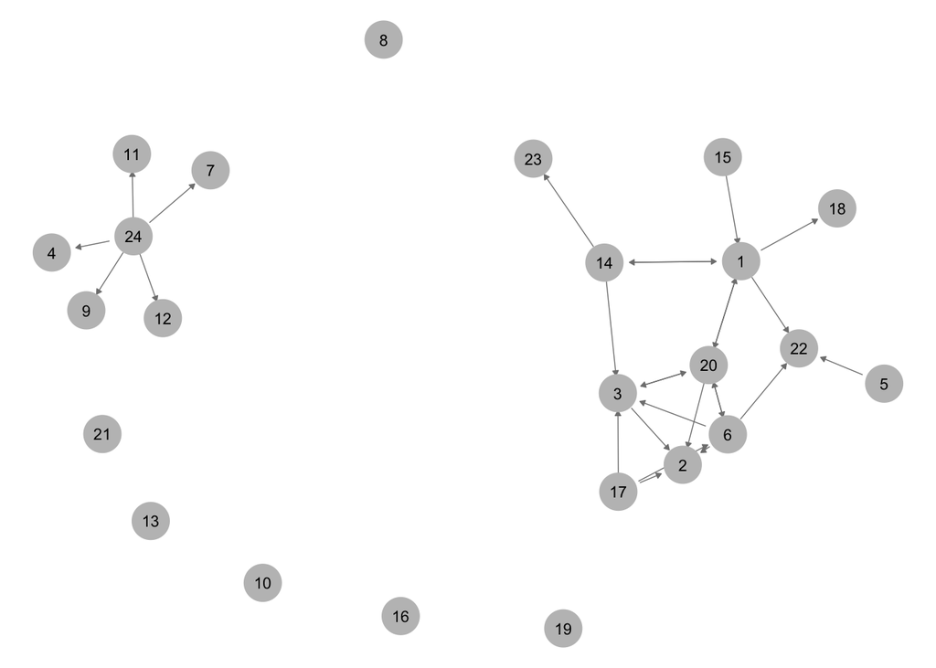

```r
ggnet2(neg_net.list[[1]],
       label = TRUE,
       label.size = 3,
       arrow.size = 3,
       arrow.gap = .03)
```

### Calculate Negative Friendship Network measures

```r
neg_mat.list <- lapply(neg_net.list, as.matrix)
neg_indegree.list <- lapply(neg_mat.list, degree, cmode = "indegree", gmode = "digraph", diag = FALSE)
neg_outdegree.list <- lapply(neg_mat.list, degree, cmode = "outdegree", gmode = "digraph", diag = FALSE)
#bonpow.list <- lapply(mat.list, bonpow, diag = FALSE)
  # error? singular?
```

```r
neg_a.list <- lapply(neg_net.list, get.vertex.attribute, "vertex.names")
neg_netm <- mapply(cbind, neg_a.list, neg_class.list, neg_indegree.list, neg_outdegree.list)
neg_netm <- lapply(neg_netm, as.data.frame)
neg_netm <- as.data.frame(do.call(rbind, neg_netm))
names(neg_netm) <- c("youthid", "classid", "neg_indegree", "neg_outdegree")

# computate isolate measure
neg_netm <- neg_netm %>%
  mutate(neg_isolate = ifelse(neg_indegree == 0 & neg_outdegree == 0, 1, 0),
         youthid_chr = as.character(youthid),
         classid_chr = as.character(classid),
         youthid_nchr = nchar(youthid_chr) # count the number of characters
         )

# add 0 to single digit youthid
neg_netm$youthid_chr[neg_netm$youthid_nchr == 1] <- paste0("0", neg_netm$youthid_chr[neg_netm$youthid_nchr == 1])

# change to numeric youthid
neg_netm$youthid <- as.numeric(paste0(neg_netm$classid_chr, neg_netm$youthid_chr))

neg_netm <- neg_netm |>
  select(youthid, classid, neg_indegree, neg_outdegree, neg_isolate)
```

```r
haven::write_dta(neg_netm, "Data-Stata/our_data/w1_neg_netm.dta")
```

```r
#merge network centrality measures
w1_netm <- merge(neg_netm, pos_netm, by = "youthid") |>
  rename(youthidCUF = youthid)

#why are these different lengths?? we do not have all network measure for all observations....
length(unique(neg_netm$youthid))
```

```
## [1] 3222
```

```r
length(unique(pos_netm$youthid))
```

```
## [1] 3221
```

```r
length(unique(w1_netm$youthidCUF))
```

```
## [1] 2007
```

```r
length(unique(w1_reciprocal_yc$youthidCUF))
```

```
## [1] 1749
```

```r
#now merge centrality measures w reciprocity measures
w1_netm <- merge(w1_netm, w1_reciprocal_yc, by = "youthidCUF")
```

Merge Network Data w Youth Main Questionnaire

```r
covars <- c("youthidCUF","classidCUF","schoolidCUF","schtype_geRV","y1_sex","y1_doby","y1_nationRV","y1_lpsc1","y1_lpsc2","y1_lpsc3","y1_lpsc4","y1_fact","y1_sat2","y1_pbsch1","y1_pbsch2","y1_pbsch3","y1_pbsch4","y1_del1","y1_del2","y1_del3","y1_del4","y1_vict1","y1_vict2","y1_vict3","y1_pdisc1","y1_pdisc2","y1_pdisc3","y1_pdisc4","y1_date","y1_contm","y1_gawm","y1_contf","y1_gawf","y1_penc1","y1_penc2","y1_penc3","y1_fcoh1","y1_fcoh2","y1_fcoh3","y1_fcoh4","y1_fcoh5","y1_pdem1","y1_pdem2","y1_pdem3","y1_pdem4","y1_pdem5","y1_pdem6","y1_pdem7","y1_pinv1","y1_pinv2","y1_pinv3","y1_tenc1","y1_tenc2")
main1 <- w1_ym[covars]
main1 <- merge(main1, w1_netm, by = "youthidCUF")

# change gender/ nationality / school type as factor
main1 <- main1 %>%
  mutate(sex = as.factor(y1_sex),
         schooltype = as.factor(schtype_geRV),
         nationality = as.factor(y1_nationRV))

main1[main1 < 0] <- NA
main1$age <- 2010 - main1$y1_doby

summary(main1)
```

```
##    youthidCUF         classidCUF      schoolidCUF    schtype_geRV
##  Min.   :10200114   Min.   :102001   Min.   :1020   Min.   :1.000
##  1st Qu.:20350418   1st Qu.:203504   1st Qu.:2035   1st Qu.:3.000
##  Median :30030314   Median :300303   Median :3003   Median :4.000
##  Mean   :32412846   Mean   :324128   Mean   :3241   Mean   :3.477
##  3rd Qu.:45860324   3rd Qu.:458603   3rd Qu.:4586   3rd Qu.:4.000
##  Max.   :59530217   Max.   :595302   Max.   :5953   Max.   :5.000
##
##      y1_sex         y1_doby      y1_nationRV       y1_lpsc1        y1_lpsc2
##  Min.   :1.000   Min.   :1993   Min.   :1.000   Min.   :2.000   Min.   :2.000
##  1st Qu.:1.000   1st Qu.:1995   1st Qu.:1.000   1st Qu.:4.000   1st Qu.:4.000
##  Median :2.000   Median :1995   Median :1.000   Median :4.000   Median :5.000
##  Mean   :1.564   Mean   :1995   Mean   :1.357   Mean   :4.255   Mean   :4.459
##  3rd Qu.:2.000   3rd Qu.:1996   3rd Qu.:1.000   3rd Qu.:5.000   3rd Qu.:5.000
##  Max.   :2.000   Max.   :1997   Max.   :3.000   Max.   :5.000   Max.   :5.000
##                  NA's   :1      NA's   :12      NA's   :1       NA's   :4
##     y1_lpsc3        y1_lpsc4        y1_fact       y1_sat2         y1_pbsch1
##  Min.   :2.000   Min.   :1.000   Min.   :1.0   Min.   : 1.000   Min.   :1.000
##  1st Qu.:4.000   1st Qu.:3.000   1st Qu.:3.0   1st Qu.: 5.000   1st Qu.:4.000
##  Median :4.000   Median :4.000   Median :4.0   Median : 7.000   Median :4.000
##  Mean   :4.207   Mean   :3.887   Mean   :3.6   Mean   : 6.438   Mean   :4.282
##  3rd Qu.:5.000   3rd Qu.:4.000   3rd Qu.:4.0   3rd Qu.: 8.000   3rd Qu.:5.000
##  Max.   :5.000   Max.   :5.000   Max.   :4.0   Max.   :10.000   Max.   :5.000
##  NA's   :4       NA's   :5       NA's   :54    NA's   :8        NA's   :4
##    y1_pbsch2       y1_pbsch3       y1_pbsch4        y1_del1
##  Min.   :1.000   Min.   :1.000   Min.   :1.000   Min.   :1.000
##  1st Qu.:4.000   1st Qu.:5.000   1st Qu.:4.000   1st Qu.:2.000
##  Median :5.000   Median :5.000   Median :4.000   Median :2.000
##  Mean   :4.438   Mean   :4.786   Mean   :4.245   Mean   :1.918
##  3rd Qu.:5.000   3rd Qu.:5.000   3rd Qu.:5.000   3rd Qu.:2.000
##  Max.   :5.000   Max.   :5.000   Max.   :5.000   Max.   :2.000
##  NA's   :3       NA's   :4       NA's   :4       NA's   :188
##     y1_del2         y1_del3         y1_del4         y1_vict1       y1_vict2
##  Min.   :1.000   Min.   :1.000   Min.   :1.000   Min.   :1.00   Min.   :1.000
##  1st Qu.:2.000   1st Qu.:2.000   1st Qu.:2.000   1st Qu.:4.00   1st Qu.:3.000
##  Median :2.000   Median :2.000   Median :2.000   Median :4.00   Median :4.000
##  Mean   :1.958   Mean   :1.901   Mean   :1.829   Mean   :3.78   Mean   :3.544
##  3rd Qu.:2.000   3rd Qu.:2.000   3rd Qu.:2.000   3rd Qu.:4.00   3rd Qu.:4.000
##  Max.   :2.000   Max.   :2.000   Max.   :2.000   Max.   :4.00   Max.   :4.000
##  NA's   :187     NA's   :187     NA's   :188     NA's   :5      NA's   :7
```

[output cut: 73 more lines]

```
##  Min.   :0.000   Min.   :0.000   Min.   :0.00   1:486   1:137      -99: 10
##  1st Qu.:1.000   1st Qu.:2.000   1st Qu.:3.00   2:628   2: 35      -88:  2
##  Median :2.000   Median :3.000   Median :4.00           3:362      1  :858
##  Mean   :1.835   Mean   :2.586   Mean   :3.89           4:320      2  : 95
##  3rd Qu.:3.000   3rd Qu.:4.000   3rd Qu.:5.00           5:260      3  :149
##  Max.   :5.000   Max.   :5.000   Max.   :5.00
##
##       age
##  Min.   :13.00
##  1st Qu.:14.00
##  Median :15.00
##  Mean   :14.68
##  3rd Qu.:15.00
##  Max.   :17.00
##  NA's   :1
```

# Exploratory Data Analysis

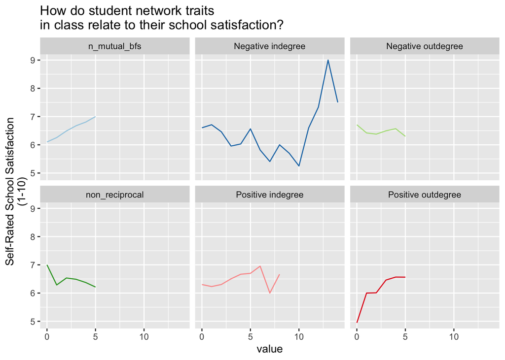

```r
library(gridExtra)
library(ggpubr)
##note these visualizaions do NOT INCLUDE COVARIATES!!! S
#we should create new visualizations after fitting models that show the relationships controlling for other covariates

main1 <- main1 |>
  mutate(pos_isolate = as.factor(pos_isolate)) |>
  mutate(neg_isolate = as.factor(neg_isolate))

main1 |>
  select(y1_sat2, neg_indegree, neg_outdegree, pos_indegree, pos_outdegree, n_mutual_bfs, non_reciprocal) |>
  #mutate_at(vars(-c(y1_sat2)), scale) |>
  pivot_longer(cols = -c(y1_sat2),
               names_to = "network_trait",
               values_to = "value") |>
  ggplot(aes(y = y1_sat2, x = value, color = network_trait)) +
  facet_wrap(~network_trait, labeller = function(variable, value){
    value <- gsub("neg_", "Negative ", value)
    value <- gsub("pos_", "Positive ", value)
    return(value)
  }) +
  stat_summary(geom = "line", fun = "mean") +
  scale_color_brewer(palette = "Paired") +
  labs(y = 'Self-Rated School Satisfaction\n(1-10)', title = 'How do student network traits\nin class relate to their school satisfaction?')+
  theme(legend.position = "none")
```

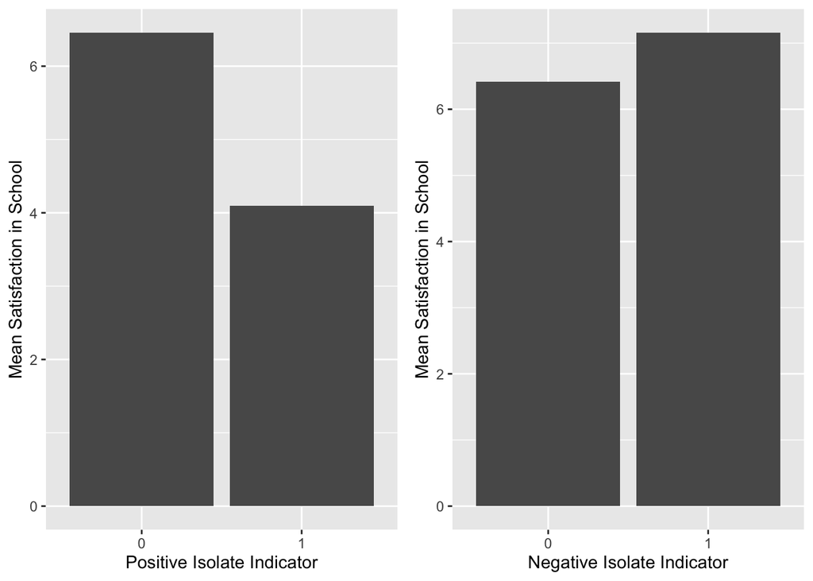

```r
p1 <- ggplot(aes(x = pos_isolate, y = y1_sat2), data = main1)+
  stat_summary(geom = "bar", fun = "mean")+
  labs(x = "Positive Isolate Indicator", y = "Mean Satisfaction in School")

p2 <- ggplot(aes(x = neg_isolate, y = y1_sat2), data = main1)+
  stat_summary(geom = "bar", fun = "mean")+
  labs(x = "Negative Isolate Indicator", y = "Mean Satisfaction in School")

bar_plots <- ggarrange(p1, p2, ncol = 2)
bar_plots
```

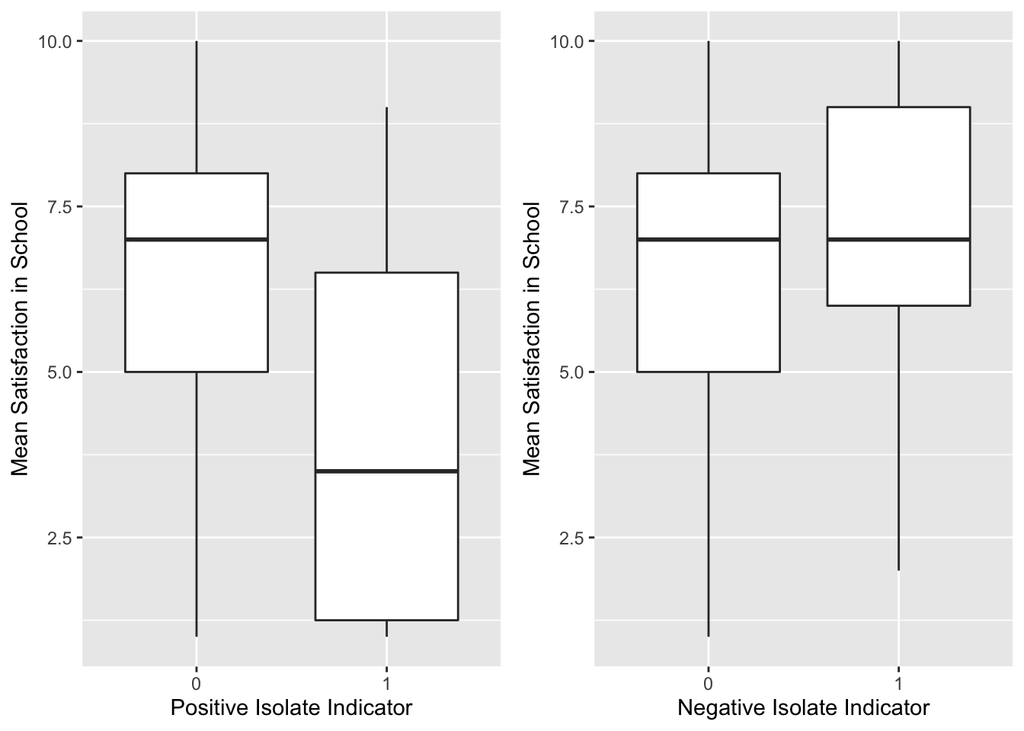

```r
p1box <- ggplot(aes(x = pos_isolate, y = y1_sat2), data = main1)+
  geom_boxplot()+
  labs(x = "Positive Isolate Indicator", y = "Mean Satisfaction in School")

p2box <- ggplot(aes(x = neg_isolate, y = y1_sat2), data = main1)+
  geom_boxplot()+
  labs(x = "Negative Isolate Indicator", y = "Mean Satisfaction in School")

box_plots <- ggarrange(p1box, p2box, ncol = 2)
box_plots
```

```r
#"How is being an Isolate in a Network related to School Satisfaction?")
```

Add some plots, correlation matrix

```r
d_cor <- dplyr::select(main1, pos_indegree, pos_outdegree, neg_indegree, neg_outdegree, n_mutual_bfs, non_reciprocal)
cor(d_cor)
```

```
##                pos_indegree pos_outdegree neg_indegree neg_outdegree
## pos_indegree     1.00000000    0.31844828  -0.27902202   -0.03694133
## pos_outdegree    0.31844828    1.00000000  -0.18979170    0.08962734
## neg_indegree    -0.27902202   -0.18979170   1.00000000   -0.01725884
## neg_outdegree   -0.03694133    0.08962734  -0.01725884    1.00000000
## n_mutual_bfs     0.82700968    0.39002880  -0.20108102   -0.03918831
## non_reciprocal  -0.59811844    0.31861184   0.07020269    0.11003108
##                n_mutual_bfs non_reciprocal
## pos_indegree     0.82700968    -0.59811844
## pos_outdegree    0.39002880     0.31861184
## neg_indegree    -0.20108102     0.07020269
## neg_outdegree   -0.03918831     0.11003108
## n_mutual_bfs     1.00000000    -0.72127943
## non_reciprocal  -0.72127943     1.00000000
```

```r
cormat <- cor(d_cor)

long_cormat <- cormat |>
  as.data.frame() |>
  mutate(var1 = rownames(cormat)) |>
  pivot_longer(-var1, names_to = 'var2', values_to = 'r')

  # Get upper triangle of the correlation matrix
  get_upper_tri <- function(cormat){
    cormat[lower.tri(cormat)]<- NA
    return(cormat)
  }

upper_tri <- get_upper_tri(cormat)
upper_tri
```

```
##                pos_indegree pos_outdegree neg_indegree neg_outdegree
## pos_indegree              1     0.3184483   -0.2790220   -0.03694133
## pos_outdegree            NA     1.0000000   -0.1897917    0.08962734
## neg_indegree             NA            NA    1.0000000   -0.01725884
## neg_outdegree            NA            NA           NA    1.00000000
## n_mutual_bfs             NA            NA           NA            NA
## non_reciprocal           NA            NA           NA            NA
##                n_mutual_bfs non_reciprocal
## pos_indegree     0.82700968    -0.59811844
## pos_outdegree    0.39002880     0.31861184
## neg_indegree    -0.20108102     0.07020269
## neg_outdegree   -0.03918831     0.11003108
## n_mutual_bfs     1.00000000    -0.72127943
## non_reciprocal           NA     1.00000000
```

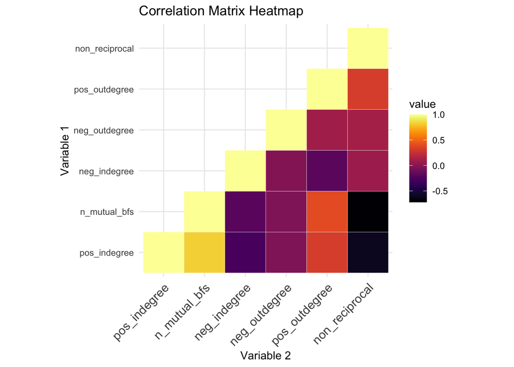

```r
reorder_cormat <- function(cormat){
# Use correlation between variables as distance
dd <- as.dist((1-cormat)/2)
hc <- hclust(dd)
cormat <-cormat[hc$order, hc$order]
}

cormat <- reorder_cormat(cormat)
upper_tri <- get_upper_tri(cormat)
# Melt the correlation matrix
melted_cormat <- melt(upper_tri, na.rm = TRUE)
# Create a ggheatmap
ggheatmap <- ggplot(melted_cormat, aes(Var2, Var1, fill = value))+
 geom_tile(color = "white")+
  scale_fill_viridis(option = "B", discrete = FALSE)+
  theme_minimal()+ # minimal theme
 theme(axis.text.x = element_text(angle = 45, vjust = 1,
    size = 12, hjust = 1))+
 coord_fixed()+
  labs(x = 'Variable 2', y = 'Variable 1', title = 'Correlation Matrix Heatmap')

# Print the heatmap
print(ggheatmap)
```

# Covariate Exploration

### Demographics & School-related Variables

#### School Type (Germany) — `schtype_geRV`

- 1 = Lower secondary school
- 2 = School combining several tracks
- 3 = Intermediate secondary school
- 4 = Comprehensive school / Rudolf-Steiner School
- 5 = Upper secondary school
- 6 = School for special needs

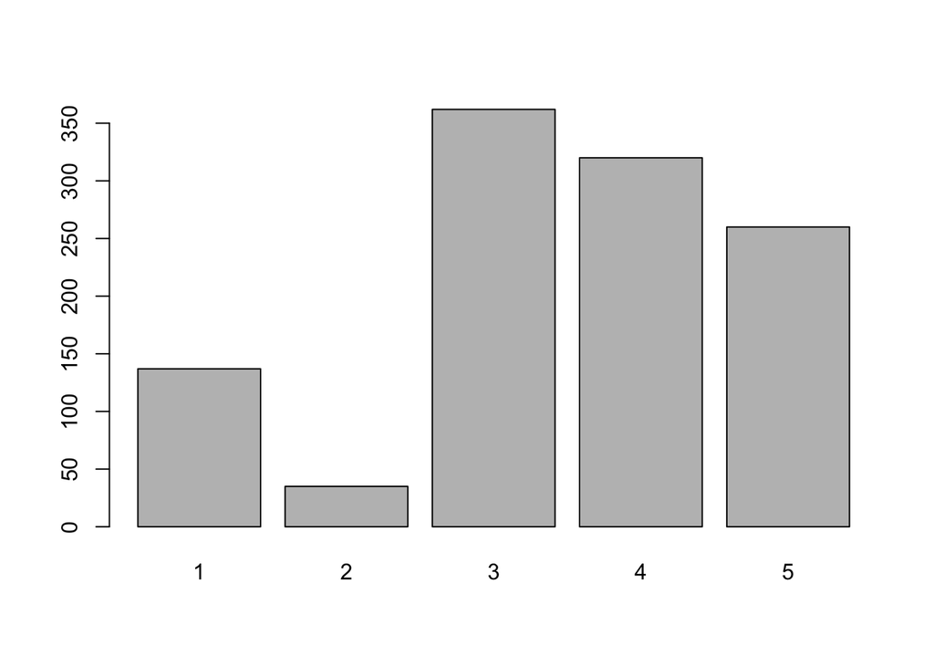

```
## main1$schtype_geRV
##       Frequency Percent
## 1           137  12.298
## 2            35   3.142
## 3           362  32.496
## 4           320  28.725
## 5           260  23.339
## Total      1114 100.000
```

```r
# univariate analysis of school type
descr::freq(main1$schtype_geRV)
```

#### Language

##### `y1_lpsc1` How well can you speak German [survey country language] ?

- 1 = Not at all
- 2 = Not well
- 3 = Well
- 4 = Very well
- 5 = Excellently

##### `y1_lpsc2` How well can you understand German?

##### `y1_lpsc3` read German | `y1_lpsc4` write German

### Language measures – proficiency in survey country language (German)

- 5-point Likert type (1 = Not at all, 2 = Not well … 5 = Excellently)
- four sub-measures regarding speak, read, write, understand

Data manipulation –> recode them into 0 to 4 for each measure and sum them up

```r
# recode multiple variables whose levels are 1 to 5 into 0 to 4
main2 <- main1 %>%
  mutate_at(vars(y1_lpsc1:y1_lpsc4), funs(.-1))

# check summary stats
print("Before recoding")
```

```
## [1] "Before recoding"
```

```r
summary((main1 %>% select(y1_lpsc1:y1_lpsc4)))
```

```
##     y1_lpsc1        y1_lpsc2        y1_lpsc3        y1_lpsc4
##  Min.   :2.000   Min.   :2.000   Min.   :2.000   Min.   :1.000
##  1st Qu.:4.000   1st Qu.:4.000   1st Qu.:4.000   1st Qu.:3.000
##  Median :4.000   Median :5.000   Median :4.000   Median :4.000
##  Mean   :4.255   Mean   :4.459   Mean   :4.207   Mean   :3.887
##  3rd Qu.:5.000   3rd Qu.:5.000   3rd Qu.:5.000   3rd Qu.:4.000
##  Max.   :5.000   Max.   :5.000   Max.   :5.000   Max.   :5.000
##  NA's   :1       NA's   :4       NA's   :4       NA's   :5
```

```r
print("After recoding")
```

```
## [1] "After recoding"
```

```r
summary((main2 %>% select(y1_lpsc1:y1_lpsc4)))
```

```
##     y1_lpsc1        y1_lpsc2        y1_lpsc3        y1_lpsc4
##  Min.   :1.000   Min.   :1.000   Min.   :1.000   Min.   :0.000
##  1st Qu.:3.000   1st Qu.:3.000   1st Qu.:3.000   1st Qu.:2.000
##  Median :3.000   Median :4.000   Median :3.000   Median :3.000
##  Mean   :3.255   Mean   :3.459   Mean   :3.207   Mean   :2.887
##  3rd Qu.:4.000   3rd Qu.:4.000   3rd Qu.:4.000   3rd Qu.:3.000
##  Max.   :4.000   Max.   :4.000   Max.   :4.000   Max.   :4.000
##  NA's   :1       NA's   :4       NA's   :4       NA's   :5
```

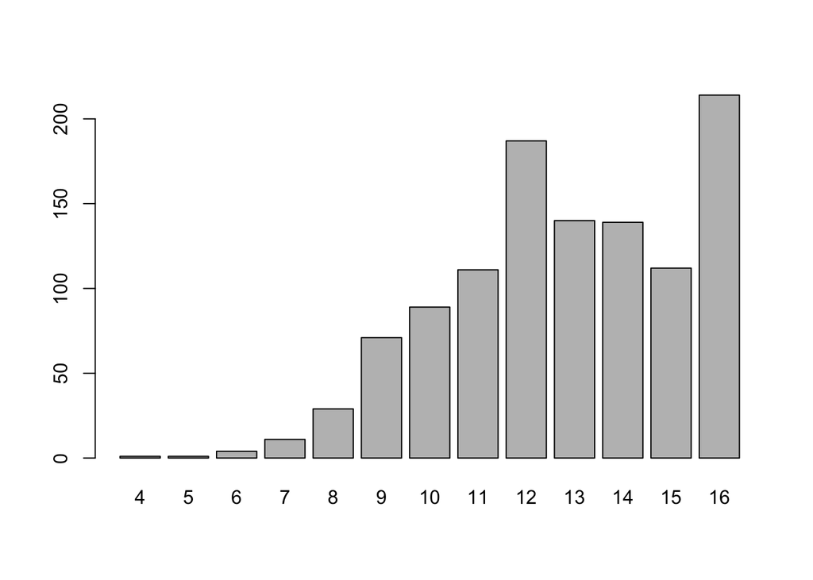

```
## main2$language
##       Frequency   Percent Valid Percent
## 4             1   0.08977       0.09017
## 5             1   0.08977       0.09017
## 6             4   0.35907       0.36069
## 7            11   0.98743       0.99188
## 8            29   2.60323       2.61497
## 9            71   6.37343       6.40216
## 10           89   7.98923       8.02525
## 11          111   9.96409      10.00902
## 12          187  16.78636      16.86204
## 13          140  12.56732      12.62399
## 14          139  12.47756      12.53381
## 15          112  10.05386      10.09919
## 16          214  19.21005      19.29666
## NA's          5   0.44883
## Total      1114 100.00000     100.00000
```

```r
main2 <- main2 %>%
  mutate(language = y1_lpsc1 + y1_lpsc2 + y1_lpsc3 + y1_lpsc4)
descr::freq(main2$language)
```

#### Gender — `y1_sex`

- 1 = Boy
- 2 = Girl

```r
# add factor variable of gender
main2$gender = ifelse(main2$y1_sex == 1, "Boy", "Girl")
descr::freq(main2$gender, plot = FALSE)
```

```
## main2$gender
##       Frequency Percent
## Boy         486   43.63
## Girl        628   56.37
## Total      1114  100.00
```

#### Age — `y1_doby` (when were you born? Year)

```r
descr::freq(main2$age, plot = FALSE)
```

```
## main2$age
##       Frequency   Percent Valid Percent
## 13            8   0.71813        0.7188
## 14          471  42.28007       42.3181
## 15          516  46.31957       46.3612
## 16          107   9.60503        9.6137
## 17           11   0.98743        0.9883
## NA's          1   0.08977
## Total      1114 100.00000      100.0000
```

#### Migration age — `y1_migage` (how old were you when you moved to [survey country]?)

#### Nationality — `y1_nationRV`

- 1 = Only survey country nationality
- 2 = Survey country and other nationality
- 3 = Only other nationality

```r
main2 <- main2 %>%
  mutate(nationality = case_when(
    y1_nationRV == 1 ~ "German only",
    y1_nationRV == 2 ~ "German and other nationality",
    y1_nationRV == 3 ~ "Only other nationality",),
    nationality = factor(nationality,
                            levels=c("German only",
                                     "German and other nationality",
                                     "Only other nationality")))

# check for recoding
print("Before recoding")
```

```
## [1] "Before recoding"
```

```r
descr::freq(main1$y1_nationRV,plot = FALSE)
```

```
## main1$y1_nationRV
##       Frequency Percent Valid Percent
## 1           858  77.020        77.858
## 2            95   8.528         8.621
## 3           149  13.375        13.521
## NA's         12   1.077
## Total      1114 100.000       100.000
```

```r
print("After recoding")
```

```
## [1] "After recoding"
```

```r
descr::freq(main2$nationality,plot = FALSE)
```

```
## main2$nationality
##                              Frequency Percent Valid Percent
## German only                        858  77.020        77.858
## German and other nationality        95   8.528         8.621
## Only other nationality             149  13.375        13.521
## NA's                                12   1.077
## Total                             1114 100.000       100.000
```

##### Correlation Matrix

```r
library(corrplot)
library(Hmisc)

mydata.cor = cor(na.omit(main1[,-c(1:3,6)]), method = c("spearman"))
mydata.cor
corrplot(mydata.cor, method = "color")
```

[output not shown]

##### Summary Statistics

```r
# change gender/ nationality / school type as factor
summary(main1 %>%
  mutate(classidCUF = as.factor(classidCUF),
         schoolidCUF = as.factor(schoolidCUF),
         y1_sex = as.factor(y1_sex),
         schtype_geRV = as.factor(schtype_geRV),
         y1_nationRV = as.factor(y1_nationRV),
         y1_fact = as.factor(y1_fact)) %>%
  select(-youthidCUF))
```

[output not shown]

## Economic situation

### `y1_fact` — can’t afford friends’ activities

- 1 = Always
- 2 = Often
- 3 = Sometimes
- 4 = Never

```r
descr::freq(main1$y1_fact, plot = FALSE)
```

```
## main1$y1_fact
##       Frequency Percent Valid Percent
## 1            22   1.975         2.075
## 2            44   3.950         4.151
## 3           270  24.237        25.472
## 4           724  64.991        68.302
## NA's         54   4.847
## Total      1114 100.000       100.000
```

## Structual Integration

### Deviance & Delinquency at school

#### `y1_pbsch1` How often do exihibit following problem behaviors in school?

argue with teacher | get a punishment in school (e.g. being kept in detention, sent out of class, writing lines) | skip a lesson without permission? | come late to school?

Response:

- 1 = every day
- 2 = once or several times a week
- 3 = once or several times a month
- 4 = less often
- 5 = never

```r
# recoding problem behavioral measures
main2 <- main2 %>%
  mutate_at(vars(y1_pbsch1:y1_pbsch4), ~ 5-.) %>%
  mutate(problem_behaviors = y1_pbsch1 + y1_pbsch2 + y1_pbsch3 + y1_pbsch4)
# check before recoding
print("Before recoding")
```

```
## [1] "Before recoding"
```

```r
descr::freq(main1$y1_pbsch1, plot = FALSE)
```

```
## main1$y1_pbsch1
##       Frequency  Percent Valid Percent
## 1             9   0.8079        0.8108
## 2            50   4.4883        4.5045
## 3            96   8.6176        8.6486
## 4           419  37.6122       37.7477
## 5           536  48.1149       48.2883
## NA's          4   0.3591
## Total      1114 100.0000      100.0000
```

```r
print("After recoding")
```

```
## [1] "After recoding"
```

```r
descr::freq(main2$y1_pbsch1, plot = FALSE)
```

```
## main2$y1_pbsch1
##       Frequency  Percent Valid Percent
## 0           536  48.1149       48.2883
## 1           419  37.6122       37.7477
## 2            96   8.6176        8.6486
## 3            50   4.4883        4.5045
## 4             9   0.8079        0.8108
## NA's          4   0.3591
## Total      1114 100.0000      100.0000
```

```r
print("Frequency of problem behaviors")
```

```
## [1] "Frequency of problem behaviors"
```

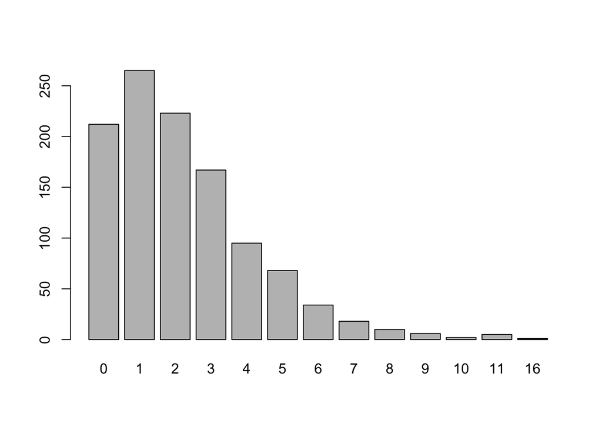

```
## main2$problem_behaviors
##       Frequency   Percent Valid Percent
## 0           212  19.03052      19.16817
## 1           265  23.78815      23.96022
## 2           223  20.01795      20.16275
## 3           167  14.99102      15.09946
## 4            95   8.52783       8.58951
## 5            68   6.10413       6.14828
## 6            34   3.05206       3.07414
## 7            18   1.61580       1.62749
## 8            10   0.89767       0.90416
## 9             6   0.53860       0.54250
## 10            2   0.17953       0.18083
## 11            5   0.44883       0.45208
## 16            1   0.08977       0.09042
## NA's          8   0.71813
## Total      1114 100.00000     100.00000
```

```r
descr::freq(main2$problem_behaviors)
```

#### `y1_del1` — Delinquent behavior: Deliberately damaged things that were not yours

```r
main2 <- main2 %>%
  mutate_at(vars(y1_del1:y1_del4),
            funs(replace(., . == 2,0)))

print("Before recoding")
```

```
## [1] "Before recoding"
```

```r
summary(main1 %>% mutate_at(vars(y1_del1:y1_del4), as.factor) %>% select(y1_del1 : y1_del4))
```

```
##  y1_del1    y1_del2    y1_del3    y1_del4
##  1   : 76   1   : 39   1   : 92   1   :158
##  2   :850   2   :888   2   :835   2   :768
##  NA's:188   NA's:187   NA's:187   NA's:188
```

```r
print("After recoding")
```

```
## [1] "After recoding"
```

```r
summary(main2 %>% mutate_at(vars(y1_del1:y1_del4), as.factor) %>% select(y1_del1 : y1_del4))
```

```
##  y1_del1    y1_del2    y1_del3    y1_del4
##  0   :850   0   :888   0   :835   0   :768
##  1   : 76   1   : 39   1   : 92   1   :158
##  NA's:188   NA's:187   NA's:187   NA's:188
```

```r
# if or not they have delinquency behavior
main2 <- main2 %>%
  mutate(delinquency_history = ifelse(rowSums(
    select(.,y1_del1:y1_del4) == 1) > 0,
    'yes','no'),
    delinquency_count = y1_del1 + y1_del2 + y1_del3 + y1_del4)

print("Delinquency history frequency")
```

```
## [1] "Delinquency history frequency"
```

```r
descr::freq(main2$delinquency_history,plot = FALSE)
```

```
## main2$delinquency_history
##       Frequency Percent Valid Percent
## no          659   59.16         71.24
## yes         266   23.88         28.76
## NA's        189   16.97
## Total      1114  100.00        100.00
```

```r
print("Delinquency count frequency")
```

```
## [1] "Delinquency count frequency"
```

```r
descr::freq(main2$delinquency_count,plot = FALSE)
```

```
## main2$delinquency_count
##       Frequency  Percent Valid Percent
## 0           659  59.1562       71.2432
## 1           191  17.1454       20.6486
## 2            55   4.9372        5.9459
## 3            17   1.5260        1.8378
## 4             3   0.2693        0.3243
## NA's        189  16.9659
## Total      1114 100.0000      100.0000
```

### Discrimination at school

Note that we donnot use perceived discrimination measures as they occur outside school setting! #### `y1_vict1:y1_vict3` – Victim at school following types: scared of other students | teased by other students | bullied by other students

Responses: - 1 = every day - 2 = once or several times a week - 3 = less often - 4 = never

```r
main2 <- main2 %>%
  mutate_at(vars(y1_vict1:y1_vict3),  ~4-.)

print("Before recoding")
```

```
## [1] "Before recoding"
```

```r
summary(main1 %>% mutate_at(vars(y1_vict1:y1_vict3), as.factor) %>% select(y1_vict1:y1_vict3))
```

```
##  y1_vict1   y1_vict2   y1_vict3
##  1   :  3   1   : 17   1   :  8
##  2   : 28   2   : 65   2   : 46
##  3   :179   3   :324   3   :111
##  4   :899   4   :701   4   :942
##  NA's:  5   NA's:  7   NA's:  7
```

```r
print("After recoding")
```

```
## [1] "After recoding"
```

```r
summary(main2 %>% mutate_at(vars(y1_vict1:y1_vict3), as.factor) %>% select(y1_vict1:y1_vict3))
```

```
##  y1_vict1   y1_vict2   y1_vict3
##  0   :899   0   :701   0   :942
##  1   :179   1   :324   1   :111
##  2   : 28   2   : 65   2   : 46
##  3   :  3   3   : 17   3   :  8
##  NA's:  5   NA's:  7   NA's:  7
```

```r
main2 <- main2 %>%
  mutate(victim_history = ifelse(rowSums(
    select(.,y1_vict1:y1_vict3) == 1) > 0,
    1,0)) %>%
  mutate_at(vars(y1_vict1:y1_vict3),
         funs(ifelse(. == 3, 5, # every day
                     ifelse(. == 2, 4, # once or several times a week
                            ifelse(. == 1, 2, .) # less often
                            )
                     )
              )
         ) # never
main2 <- main2 %>%
  mutate(victim_history_score = y1_vict1 + y1_vict2 + y1_vict3)
descr::freq(main2$victim_history,plot = FALSE)
```

```
## main2$victim_history
##       Frequency  Percent Valid Percent
## 0           682  61.2208         61.66
## 1           424  38.0610         38.34
## NA's          8   0.7181
## Total      1114 100.0000        100.00
```

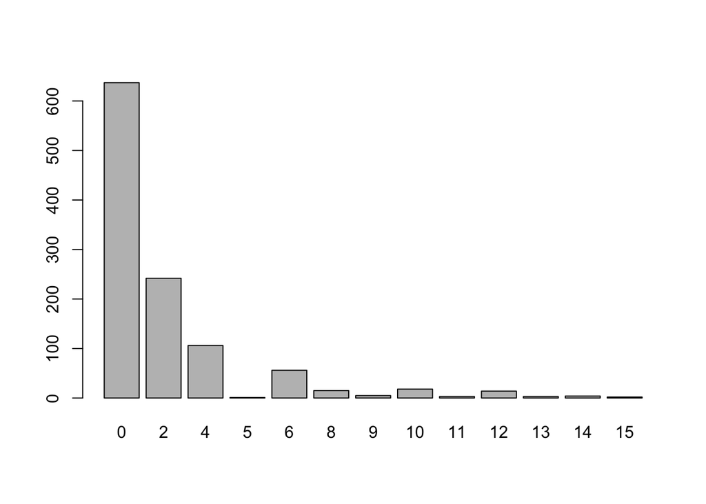

```
## main2$victim_history_score
##       Frequency   Percent Valid Percent
## 0           637  57.18133      57.59494
## 2           242  21.72352      21.88065
## 4           106   9.51526       9.58409
## 5             1   0.08977       0.09042
## 6            56   5.02693       5.06329
## 8            15   1.34650       1.35624
## 9             5   0.44883       0.45208
## 10           18   1.61580       1.62749
## 11            3   0.26930       0.27125
## 12           14   1.25673       1.26582
## 13            3   0.26930       0.27125
## 14            4   0.35907       0.36166
## 15            2   0.17953       0.18083
## NA's          8   0.71813
## Total      1114 100.00000     100.00000
```

```r
descr::freq(main2$victim_history_score)
```

```r
print("After recoding stage two")
```

```
## [1] "After recoding stage two"
```

```r
summary(main2 %>% mutate_at(vars(y1_vict1:y1_vict3), as.factor) %>% select(y1_vict1:y1_vict3))
```

```
##  y1_vict1   y1_vict2   y1_vict3
##  0   :899   0   :701   0   :942
##  2   :179   2   :324   2   :111
##  4   : 28   4   : 65   4   : 46
##  5   :  3   5   : 17   5   :  8
##  NA's:  5   NA's:  7   NA's:  7
```

### Family

#### Family Relation

##### `y1_gawm | y1_gawf` — how well do you get along with your mother/father?

- 1 = every very well
- 2 = well
- 3 = not so well
- 4 = not well at all

```r
# if or not they have delinquency behavior
main2 <- main2 %>%
  mutate_at(vars(y1_gawm,y1_gawf), ~4-.) %>%
  mutate(parent_relation = round((y1_gawf + y1_gawm)/2)) # average score of how well they get along with parents

print("Before recoding")
```

```
## [1] "Before recoding"
```

```r
summary(main1 %>% mutate_at(vars(y1_gawm,y1_gawf), as.factor) %>% select(y1_gawm,y1_gawf))
```

```
##  y1_gawm    y1_gawf
##  1   :615   1   :534
##  2   :409   2   :396
##  3   : 53   3   : 69
##  4   : 11   4   :  8
##  NA's: 26   NA's:107
```

```r
print("After recoding")
```

```
## [1] "After recoding"
```

```r
summary(main2 %>% mutate_at(vars(y1_gawm,y1_gawf), as.factor) %>% select(y1_gawm,y1_gawf))
```

```
##  y1_gawm    y1_gawf
##  0   : 11   0   :  8
##  1   : 53   1   : 69
##  2   :409   2   :396
##  3   :615   3   :534
##  NA's: 26   NA's:107
```

```r
print("Parental relation")
```

```
## [1] "Parental relation"
```

```r
descr::freq(main2$parent_relation,plot = FALSE)
```

```
## main2$parent_relation
##       Frequency  Percent Valid Percent
## 0             2   0.1795        0.2022
## 1            17   1.5260        1.7189
## 2           582  52.2442       58.8473
## 3           388  34.8294       39.2315
## NA's        125  11.2208
## Total      1114 100.0000      100.0000
```

## School satisfication

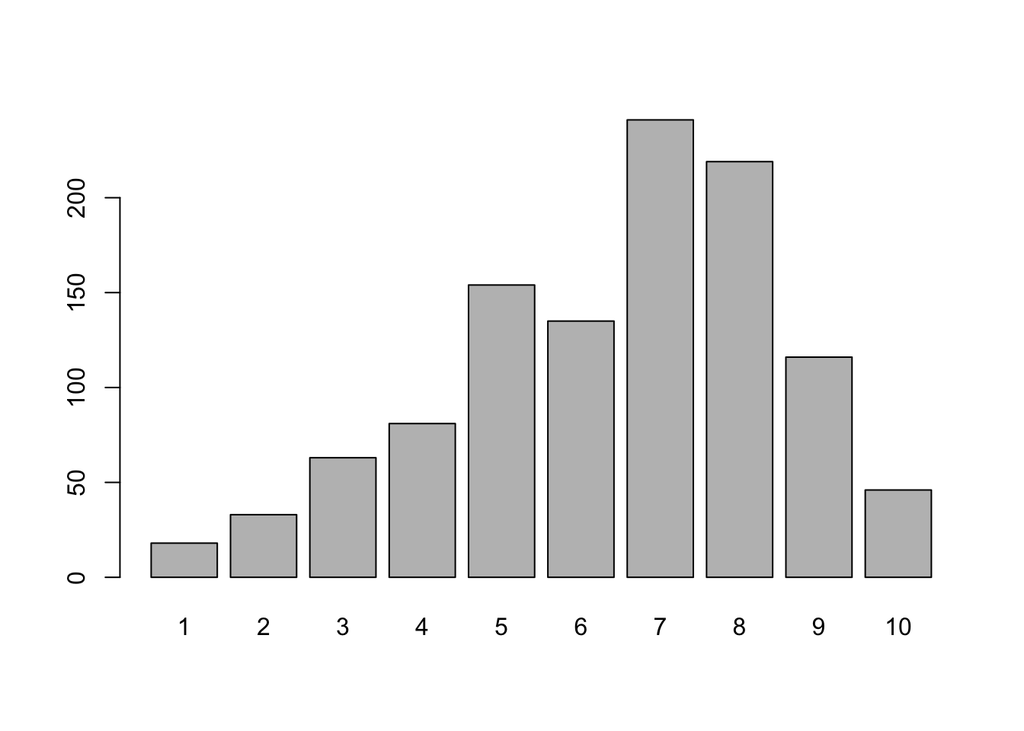

```
## main2$y1_sat2
##       Frequency  Percent Valid Percent
## 1            18   1.6158         1.627
## 2            33   2.9623         2.984
## 3            63   5.6553         5.696
## 4            81   7.2711         7.324
## 5           154  13.8241        13.924
## 6           135  12.1185        12.206
## 7           241  21.6338        21.790
## 8           219  19.6589        19.801
## 9           116  10.4129        10.488
## 10           46   4.1293         4.159
## NA's          8   0.7181
## Total      1114 100.0000       100.000
```

```r
descr::freq(main2$y1_sat2)
```

### Other measures of school satisfaction

w1: y1_asch1 How much do you agree with “School is not for ppl like me?” 1 = strongly agree, 5 = strongly disagree, w1: y1_tenc1 I get the help that I need from the teachers at school w1: y1_tenc2 My teachers encourage me at school w1: y1_tenc3 There are teachers who threat me unfairly

```r
# recoding problem behavioral measures
main2 <- main2 %>%
  mutate_at(vars(y1_tenc1:y1_tenc2), ~ 5-.) %>%
  mutate(teacher_help = y1_tenc1,
         teacher_encouragement = y1_tenc2,
         teacher_support = y1_tenc1 + y1_tenc2)
# check before recoding
print("Before recoding")
```

```
## [1] "Before recoding"
```

```r
descr::freq(main1$y1_tenc1, plot = FALSE)
```

```
## main1$y1_tenc1
##       Frequency  Percent Valid Percent
## 1           147  13.1957        13.231
## 2           515  46.2298        46.355
## 3           311  27.9174        27.993
## 4           110   9.8743         9.901
## 5            28   2.5135         2.520
## NA's          3   0.2693
## Total      1114 100.0000       100.000
```

```r
print("After recoding")
```

```
## [1] "After recoding"
```

```r
descr::freq(main2$y1_tenc1, plot = FALSE)
```

```
## main2$y1_tenc1
##       Frequency  Percent Valid Percent
## 0            28   2.5135         2.520
## 1           110   9.8743         9.901
## 2           311  27.9174        27.993
## 3           515  46.2298        46.355
## 4           147  13.1957        13.231
## NA's          3   0.2693
## Total      1114 100.0000       100.000
```

```r
print("Frequency of teacher support")
```

```
## [1] "Frequency of teacher support"
```

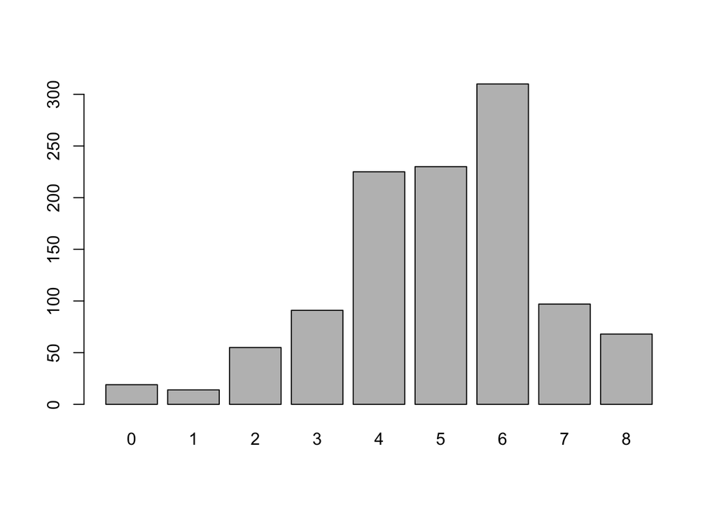

```
## main2$teacher_support
##       Frequency  Percent Valid Percent
## 0            19   1.7056         1.713
## 1            14   1.2567         1.262
## 2            55   4.9372         4.959
## 3            91   8.1688         8.206
## 4           225  20.1975        20.289
## 5           230  20.6463        20.739
## 6           310  27.8276        27.953
## 7            97   8.7074         8.747
## 8            68   6.1041         6.132
## NA's          5   0.4488
## Total      1114 100.0000       100.000
```

```r
descr::freq(main2$teacher_support)
```

```r
library(corrplot)
library(Hmisc)

mydata.cor = cor(na.omit(main2[,c("y1_sat2","teacher_support","problem_behaviors","victim_history","delinquency_count")]), method = c("spearman"))
mydata.cor
corrplot(mydata.cor, method = "color")
```

[output not shown]

### Self-esteem

#### `y1_sest1:y1_sest4` following measures:

I have a lot of good qualities | have a lot to be proud of | like myself just the way I am | think things will go well for me in the future

Response: - 1 = strongly agree - 2 = agree - 3 = neither agree nor disagree - 4 = disagree - 5 = strongly disagree

```r
jsonlite::write_json(main2, "Data-Stata/our_data/CILS4EU.json")
write_csv(main2, "Data-Stata/our_data/all_main.csv")
```